# Mean Reversion Algorithmic Trading Strategy

### Automated in OANDA FX Practice

#### Prepared for the "Certificate Program for Algorithmic Trading with Python"

#### Emrah Ozpeynirci - November 2017

### Abstract

This project aims to demonstrate how to compute a mean reversion algorithmic trading strategy on any choosen currency pair. Most currency pairs price series are not mean reverting, but they are geometric random walks. It is the returns, not the prices, are the ones that usually randomly distributed around the mean of zero. Unfortunately, one can not trade on the mean reversion of returns. Therefore our analysis assumes the current price level will tell something about what the next price move will be: If the price level is higher than the mean, the next move will be downward move; if the price level is lower than the mean, the next move will be an upward move. However, this description fails to convey the more complex issues, such as the difficulties in determining whether the currency pair time series behaves like a mean reverting process. Furthermore, even if the underlying stochastic process implies reversion to some equilibrium exchange rate price, this does not exclude the possibility of sustained and potential large deviations from this equilibrium. The longer the deviation from the mean persists the higher the risk of substantial equity drawdowns. Ideally, one should first obtain high confidence that the time series under consideration is indeed mean reverting and that the half life of mean reversion is sufficiently low, before allocating capital.

In the following part we start with an overview of the concept of stationarity and the relevant statistical methods that can be applied to test individual time series for mean reversion.

## Collecting the Financial Data

Time Series data has been collected using OANDA History function. We used our own config file "algotrader.pyg" which provides account information and necessary keys.

#### Imports

We used 'statsmodel' libraries extensively to conduct the necessary statistical tests to verify the mean reverting pairs. In addition, 'numpy' and 'pandas' are used for vectorization and backtesting purposes.

To connect OANDA and execute the automation a special wrapper class is used 'tpqoa'

```python
from tpqoa import tpqoa
import numpy as np
import pandas as pd
from pylab import plt
plt.style.use('seaborn')
import seaborn as sns
%matplotlib inline
from numpy import log, polyfit, sqrt, std, subtract
import statsmodels.tsa.stattools as ts
import statsmodels.api as sm

import warnings
warnings.filterwarnings('ignore')

import math

import datetime as dt

import statsmodels
import statsmodels.api as sm
from statsmodels.tsa.stattools import coint, adfuller
```

```python
oanda = tpqoa('algotrader.pyg') # config file contains account information and keys
```

```python
oanda.get_instruments() # available OANDA instruments, and we tested many of those to find the right pair which
                            # to our serves our strategy
```

```
[('Brent Crude Oil', 'BCO_USD'),
 ('Copper', 'XCU_USD'),
 ('Germany 30', 'DE30_EUR'),
 ('EUR/ZAR', 'EUR_ZAR'),
 ('US Nas 100', 'NAS100_USD'),
 ('Netherlands 25', 'NL25_EUR'),
 ('Silver/GBP', 'XAG_GBP'),
 ('EUR/HUF', 'EUR_HUF'),
 ('Silver/HKD', 'XAG_HKD'),
 ('Singapore 30', 'SG30_SGD'),
 ('EUR/NOK', 'EUR_NOK'),
 ('Gold/HKD', 'XAU_HKD'),
 ('USD/HUF', 'USD_HUF'),
 ('GBP/ZAR', 'GBP_ZAR'),
 ('Sugar', 'SUGAR_USD'),
 ('NZD/SGD', 'NZD_SGD'),
 ('CAD/JPY', 'CAD_JPY'),
 ('EUR/USD', 'EUR_USD'),
 ('EUR/JPY', 'EUR_JPY'),
 ('NZD/CHF', 'NZD_CHF'),
 ('USD/CAD', 'USD_CAD'),
 ('AUD/CAD', 'AUD_CAD'),
 ('Gold/CAD', 'XAU_CAD'),
 ('NZD/USD', 'NZD_USD'),
 ('HKD/JPY', 'HKD_JPY'),
 ('Gold/SGD', 'XAU_SGD'),
 ('CHF/JPY', 'CHF_JPY'),
 ('UK 100', 'UK100_GBP'),
 ('Gold/AUD', 'XAU_AUD'),
 ('CAD/CHF', 'CAD_CHF'),
 ('CAD/SGD', 'CAD_SGD'),
 ('EUR/SGD', 'EUR_SGD'),
 ('Silver/CAD', 'XAG_CAD'),
 ('Gold/CHF', 'XAU_CHF'),
 ('Bund', 'DE10YB_EUR'),
 ('West Texas Oil', 'WTICO_USD'),
 ('EUR/TRY', 'EUR_TRY'),
 ('USD/JPY', 'USD_JPY'),
 ('CHF/HKD', 'CHF_HKD'),
 ('Australia 200', 'AU200_AUD'),
```

[output cut: 69 more lines]

```
 ('GBP/CAD', 'GBP_CAD'),
 ('USD/SAR', 'USD_SAR'),
 ('Hong Kong 33', 'HK33_HKD'),
 ('EUR/CAD', 'EUR_CAD'),
 ('Corn', 'CORN_USD'),
 ('GBP/SGD', 'GBP_SGD'),
 ('USD/SEK', 'USD_SEK'),
 ('US 2Y T-Note', 'USB02Y_USD'),
 ('Gold', 'XAU_USD'),
 ('US Russ 2000', 'US2000_USD'),
 ('CHF/ZAR', 'CHF_ZAR'),
 ('EUR/GBP', 'EUR_GBP'),
 ('Silver/SGD', 'XAG_SGD'),
 ('AUD/CHF', 'AUD_CHF'),
 ('Wheat', 'WHEAT_USD')]
```

```python
data = oanda.get_history('AUD_NZD',start='2017-11-2', end='2017-11-3',granularity='S30',price='A') # retrieving the historical data
```

```python
data = pd.DataFrame(data['c']) # putting the historical data into a timeframe object
```

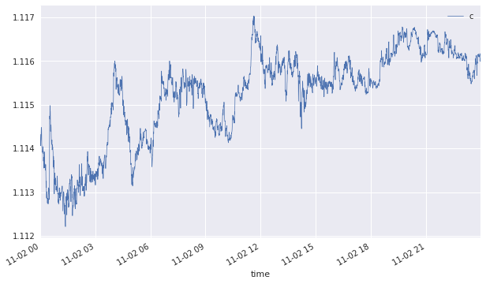

```python
data.plot(figsize=(10,6),lw=0.7); # plotting the sample data
```

## Basic Concepts on Stationarity

We can classify random processes based on many different criteria. One of the important classifications we can make about a random process is whether it is a stationary process.

A random process is stationary if its statistical properties do not change by time. In particular, its long-run "mean" and "variance" stay constant. This property is fundamental when applying linear regression and forecasting models.

Such that;

Mean of a time series $$x_t is E(x_t)=\mu(t)$$

Variance of a time series $$x_t is \sigma^2(t)=E[(x_t - \mu(t))^2]$$

A time series is stationary in the mean if $$\mu(t)=\mu$$, i.e.mean is constant with time

A time series is stationary in the variance if $$\sigma^2(t)=\sigma^2$$, i.e. variance is constant with time

Stationary time series are easy to predict because we can assume that future statistical properties would likely be the same or proportional to the current statistical beheviour.

If the series is non-stationary; it is difficult to forecast the future movements as the data varies extremely from the mean of the distribution.

## Testing for Stationarity and Unit Root

To check for stationarity, augmented Dickey-Fuller (ADF) test is applied. This is a robust method to confirm statistically whether the series is stationary or not.

### Augmented Dickey - Fuller (ADF) Unit Root Test

The Augmented Dickey-Fuller test is used for determining whether a single time series process has a unit root, and thus is non-stationary. Unit root test determines how strongly a time series is defines by a trend. There are a number of unit root tests and ADF is one of the widely used one. ADF uses an autoregressive model (AR) and optimizes an information criterion across multiple different lag values.

For example, a simple AR model is:

$$ Y_t = \beta Y_{t-1} + \epsilon_t $$

If $\beta=1$ the series is said to have a 'unit root' and is hence non-stationary. The equation can be rewriten as:

$$ \Delta Y_t = (\beta - 1) Y_{t-1} + \epsilon_t = \phi Y_{t-1} + \epsilon_t $$

where $\phi= \beta-1$. Hence, testing for unit root is equivalent to testing $\phi=0$. The value of the test statistic $\hat{\phi}/std.err(\hat{\phi})$ is then compared to the relevant critical values for the Dickey-Fuller distribution. If found lower, then the null hypothesis $\phi=0$ is rejected and the series can be considered stationary.

The null hypothesis of the test is that the time series can be represented by a unit root, that it is NOT stationary, meaning has some time-dependent structure. The alternate hypothesis (i.e. rejecting the null hypothesis), is that the time series is stationary.

Null Hypothesis (H0): If accepted, it suggests the time series has a unit root, meaning it is non-stationary. It has some time dependent structure.

Alternate Hypothesis (H1): The null hypothesis is rejected; it suggests the time series does not have a unit root, meaning it is stationary. It does not have time-dependent structure.

We can also interpret this result using the p-value from the test. A p-value below a threshold (such as 5% or 1%) suggests we reject the null hypothesis (stationary), otherwise a p-value above the threshold suggests we accept the null hypothesis (non-stationary).

p-value > 0.05: Accept the null hypothesis (H0), the data has a unit root and is non-stationary.

p-value <= 0.05: Reject the null hypothesis (H0), the data does not have a unit root and is stationary.

As a result, if the process is stationary then autoregression applies, otherwise cointegration analysis should be the preffered method.

```python
ts.adfuller(data['c'], 1)
```

```
(-2.6056808708947821,
 0.09182882208553711,
 1,
 2862,
 {'1%': -3.4326369234195746,
  '10%': -2.5673078691409787,
  '5%': -2.8625504068040923},
 -44268.800010750798)
```

The first value is the calculated test-statistic, while the second value is the p-value. The fourth is the number of data points in the sample. The fifth value, the dictionary, contains the critical values of the test-statistic at the 1, 5 and 10 percent values respectively.

Test-statistic value is negative meaning time series is not trending. We can argue this is a good currency pair to test.

The P value is 0.09 and higher than 0.05, although this indicates time series has a unit root and non-stationary. We have tested several pairs whose P values were around 0.50 - 0.90. Therefore we choose to ignore and continue with the pair.

The calculated value of the test statistic is larger than 1 and 5 percent of the critical levels but smaller than 10 percent level of the critical value, this means we can reject the null hypothesis with 90% confidence that the time series has a unit root. This means does not have a unit root. Thus, according to our ADF test we are likely to have found a mean reverting time series.

A time series (or stochastic process) is defined to be strongly stationary if its joint probability distribution is invariant under translations in time or space. In particular, key importance, the mean and variance of the process do not change over time or space and they each do not follow a trend.

A critical feature of stationary price series is that the prices within the series diffuse from their initial value at a rate slower than that of a geometric brownian motion. By measuring the rate of this diffusive behaviour we can identify the nature of the time series.

Namely the Hurst Exponent, is another test which helps us to characterise the stationarity of a time series.

### Hurst Exponent

Another way of looking at stationarity and mean reversion is from the perspective of the speed of diffusion from an initial state. A stationary series would diffuse at a slower rate than a geometric random walk. We can measure the speed of diffusion as the variance of the series:

$$Var(τ) = 〈|z(t + τ) − z(t)|^2〉$$

where

z = log(price) $τ$ is an arbitrary time lag 〈…〉 is an average over all t’s

For a geometric random walk:

$$〈|z(t + τ) − z(t)|^2〉 ∼ τ$$

Where H is the Hurst exponent, H serves as an indicator of the degree to which a series trends.

The goal of the Hurst Exponent is to provide us with a scalar value that will help us to identify (within the limits of statistical estimation) whether a series is mean reverting, random walking or trending.

The Hurst exponent is used as a measure of long-term memory of time series. It relates to the autocorrelations of the time series, and the rate at which these decrease as the lag between pairs of values increases. The Hurst exponent is referred to as the "index of dependence" or "index of long-range dependence". It quantifies the relative tendency of a time series either to regress strongly to the mean or to cluster in a direction.

A value H in the range 0.5–1 indicates a time series with long-term positive autocorrelation, meaning both that a high value in the series will probably be followed by another high value and that the values a long time into the future will also tend to be high.

A value in the range 0 – 0.5 indicates a time series with long-term switching between high and low values in adjacent pairs, meaning that a single high value will probably be followed by a low value and that the value after that will tend to be high, with this tendency to switch between high and low values lasting a long time into the future.

A value of H=0.5 can indicate a completely uncorrelated series, but in fact it is the value applicable to series for which the autocorrelations at small time lags can be positive or negative but where the absolute values of the autocorrelations decay exponentially quickly to zero. This in contrast to the typically power law decay for the 0.5 < H < 1 and 0 < H < 0.5 cases.

```python
def hurst(ts):
    """Returns the Hurst Exponent of the time series vector ts"""
    # Create the range of lag values
    lags = range(2, 250)

    # Calculate the array of the variances of the lagged differences
    tau = [sqrt(std(subtract(ts[lag:], ts[:-lag]))) for lag in lags]

    # Use a linear fit to estimate the Hurst Exponent
    poly = polyfit(log(lags), log(tau), 1)

    # Return the Hurst exponent from the polyfit output
    return poly[0]*2.0
```

```python
print(hurst(data))
```

```
[ 0.36615601]
```

Hurst value with 250 lags give 0.36, this is clearly inline with our ADF test. However, for some different time series of the same underlying currency pair we had an ADF result which signals a non-stationarity, but when we adjusted the lag size we had a meaningfull Hurst data. Sometimes, higher lag sizes pushes the exponent near to 0.00 and sometimes smaller lag sizes (ex. 10-20) takes the exponent just above 0.50.

Therefore, we can draw a significant conclusion from these results: that the lags used to calculate Hurst have a much greater impact on the calculation than the particular segment of the time series analysed.

Further, when we look at the entire time series, we see that our spread is moderately mean-reverting for both small and high lags. Lags close to 20 are least mean reverting, and then H decreases as we increase the lags used in its calculation. If we continue to increase the lags used to calculate H up to the range 150-250, we find that H indicates a more mean reverting time series.

The Hurst Exponent is under 0.5 value of a random walk and we could therefore conclude that the series is mean reverting, but with this analysis we have a number 0.36 which backs up our conclusion based on the Augmented Dickey Fuller test previously. This means that the spread series does look like a candidate for a mean reversion strategy. However just because a time series displays mean reverting properties, it doesn’t necessarily mean that we can trade it profitably either – there’s a difference between a series that deviates and mean reverts every week and one that takes 10 years to mean revert. Therefore if this spread's mean reversion takes too much time that will keep us in the position for too long. To get an idea of how long each mean reversion is going to take, we can look into the “half-life” of the time series. We can calculate this by running a linear regression between the spread series and a lagged version of itself. The Beta coefficient produced by this regression can then be incorporated into the Ornstein-Uhlenbeck process to calculate the half-life.

Below code runs an Ordinary Least Squares regression on the spread series and a lagged version of the spread series in order to use the coefficient to calculate the half-life of mean reversion.

### Halflife of a Mean Reversion

Mean reversion is one of the key trading concepts in Algorithmic Trading. This process refers to a time series that displays a tendency to revert to its historical mean value. Mathematically, such a (continuous) time series is referred to as an Ornstein-Uhlenbeck process. This is in contrast to a random walk (Brownian motion), which has no "memory" of where it has been at each particular instance of time. The mean-reverting property of a time series can be exploited in order to produce profitable trading strategies.

A continuous mean-reverting time series can be represented by an Ornstein-Uhlenbeck stochastic differential equation:

$$ dxt=θ(μ−xt)dt+σdWt $$

Where θ is the rate of reversion to the mean, μ is the mean value of the process, σ is the variance of the process and Wt is a Wiener Process or Brownian Motion.

In a discrete setting the equation states that the change of the price series in the next time period is proportional to the difference between the mean price and the current price, with the addition of Gaussian noise.

```python
spread_lag = data.shift(1) # creating a lag version
spread_lag.iloc[0] = spread_lag.iloc[1]
spread_ret = data - spread_lag
spread_ret.iloc[0] = spread_ret.iloc[1]
spread_lag2 = sm.add_constant(spread_lag)

model = sm.OLS(spread_ret,spread_lag2)
res = model.fit()

halflife = round(-np.log(2) / res.params[1],0)

if halflife <= 0:
    halflife = 1
print  (halflife)
```

```
138.0
```

We have a meaningfull and significantly low halflife of mean reversion number. This significantly backs our ADF and Hurst analysis. However, for some different time series, (12-13 November 2017, same granularity) gives us 12.0 halflife, but fails to back our ADF analysis. Therefore, we prefered to use 138 since all of statistical criterias have been satisfied.

```python
#res.summary()
```

## Strategy Backtesting

```python
data = oanda.get_history('AUD_NZD',start='2017-11-2', end='2017-11-3',granularity='S30',price='A')['c']
```

```python
data = pd.DataFrame(data)
```

```python
data.rename(columns={'c': 'price'}, inplace=True)
```

```python
data['returns'] = np.log(data['price'] / data['price'].shift(1))
```

```python
SMA = 138 # using half-life of mean reversion as SMA value
```

```python
data['SMA'] = data['price'].rolling(SMA).mean()
```

```python
data['distance'] = data['price'] - data['SMA']
```

```python
data['distance'].std() # this gives our treshold value
```

```
0.00046371296443729356
```

```python
threshold = 0.00046371296443729356
```

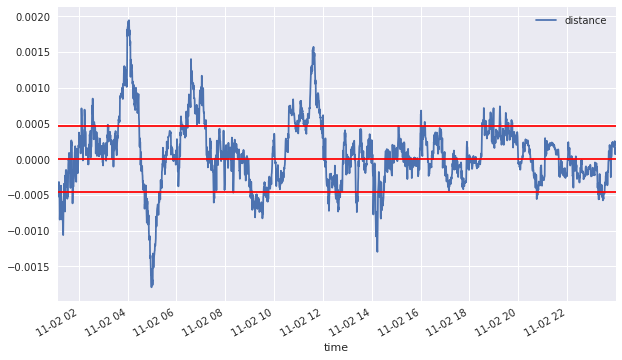

```python
data['distance'].dropna().plot(figsize=(10, 6), legend=True)
plt.axhline(threshold, color='r')
plt.axhline(-threshold, color='r')
plt.axhline(0, color='r');
```

```python
data['position'] = np.where(data['distance'] > threshold,-1, np.nan)
```

```python
data['position'] = np.where(data['distance'] < -threshold,1, data['position'])
```

```python
data['position'] = np.where(data['distance'] *data['distance'].shift(1) < 0, 0, data['position'])
```

```python
data['position'] = data['position'].ffill().fillna(0)
```

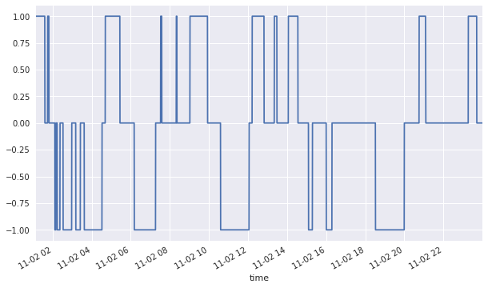

```python
data['position'].iloc[SMA:].plot(figsize=(10, 6)); # visualizing the positions (1=long, -1=short)
```

```python
data['strategy'] = data['position'].shift(1) * data['returns']
```

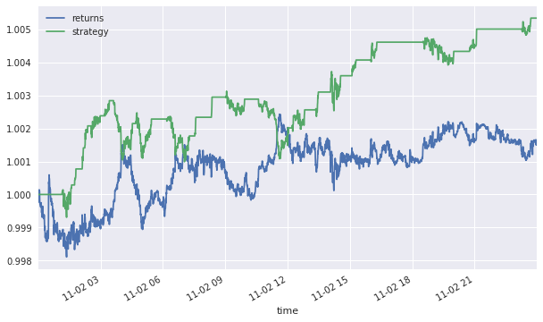

```python
data[['returns', 'strategy']].dropna().cumsum().apply(np.exp).plot(figsize=(10, 6)); # performance visualized
```

### Backtesting Class

```python
class BacktestBase(object):
    def __init__(self, symbol, start, end, granularity, amount, ftc=0.0, ptc=0.0):
        self.symbol = symbol
        self.start = start
        self.end = end
        self.granularity = granularity
        self._amount = amount
        self.amount = amount
        self.ftc = ftc
        self.ptc = ptc
        self.units = 0
        self.position = 0
        self.trades = 0
        self.verbose = True
        self.get_data()

    def get_data(self):
        ''' Retrieves and prepares the data.
        '''
        raw = oanda.get_history(self.symbol,start=self.start,
                                end=self.end, granularity=self.granularity, price='A')['c']
        raw = pd.DataFrame(raw)
        raw.rename(columns={'c': 'price'}, inplace=True)
        raw['return'] = np.log(raw / raw.shift(1))
        self.data = raw.dropna()

    def plot_data(self):
        ''' Plots the (adjusted) closing prices for symbol.
        '''
        self.data['price'].plot(figsize=(10, 6), title=self.symbol)

    def print_balance(self, date=''):
        ''' Print out current cash balance info.
        '''
        print('%s | current cash balance %8d' % (date[:10], self.amount))

    def get_date_price(self, bar):
        ''' Return date and price for bar.
        '''
        date = str(self.data.index[bar])
        price = self.data.price.ix[bar]
        return date, price

    def place_buy_order(self, bar, units=None, amount=None):
        ''' Place a buy order.
        '''
        date, price = self.get_date_price(bar)
        if units is None:
            units = math.floor(amount / price)
        self.amount -= (units * price) * (1 + self.ptc) + self.ftc
        self.units += units
        self.trades += 1
        if self.verbose:
            print('%s | buying  %4d units at %7.2f' %
                  (date[:10], units, price))
            self.print_balance(date)

    def place_sell_order(self, bar, units=None, amount=None):
        ''' Place a sell order.
        '''
        date, price = self.get_date_price(bar)
        if units is None:
            units = math.floor(amount / price)
        self.amount += (units * price) * (1 - self.ptc) - self.ftc
        self.units -= units
        self.trades += 1
        if self.verbose:
            print('%s | selling %4d units at %7.2f' %
                  (date[:10], units, price))
            self.print_balance(date)

    def close_out(self, bar):
        ''' Closing out a long or short position.
        '''
        date, price = self.get_date_price(bar)
        self.amount += self.units * price
        if self.verbose:
            print('%s | inventory %d units at %.2f' % (date[:10],
                                                       self.units, price))
        if self.verbose:
            print('=' * 55)
        print('Final balance   [$] %13.2f' % self.amount)
        print('Net Performance [%%] %13.2f' % ((self.amount - self._amount) /
                                               self._amount * 100))
        print('=' * 55)
```

```
<class 'pandas.core.frame.DataFrame'>
DatetimeIndex: 2863 entries, 2017-11-02 00:00:30 to 2017-11-02 23:59:30
Data columns (total 2 columns):
price     2863 non-null float64
return    2863 non-null float64
dtypes: float64(2)
memory usage: 67.1 KB
None
                       price    return
time
2017-11-02 23:57:30  1.11616 -0.000009
2017-11-02 23:58:00  1.11599 -0.000152
2017-11-02 23:58:30  1.11605  0.000054
2017-11-02 23:59:00  1.11599 -0.000054
2017-11-02 23:59:30  1.11607  0.000072
```

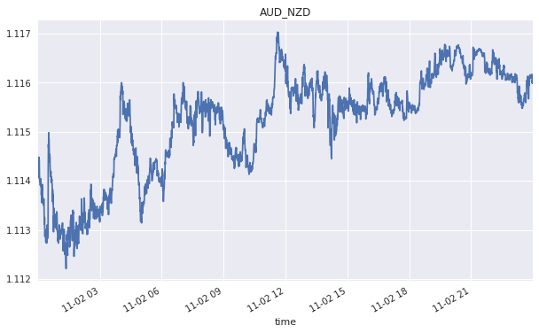

```python
if __name__ == '__main__':
    bb = BacktestBase('AUD_NZD', '2017-11-2', '2017-11-3', 'S30', 10)
    print(bb.data.info())
    print(bb.data.tail())
    bb.plot_data()
```

```python
class Backtest(BacktestBase):

    def run_mean_reversion_strategy(self, SMA, threshold):
        ''' Backtesting a mean reversion-based strategy.

        Parameters
        ==========
        SMA: int
            simple moving average in days
        threshold: float
            absolute value for deviation-based signal relative to SMA
        '''
        msg = '\n\nRunning mean reversion strategy | SMA %d & thr %d' \
            % (SMA, threshold)
        msg += '\nfixed costs %.2f | ' % self.ftc
        msg += 'proportional costs %.4f' % self.ptc
        print(msg)
        print('=' * 55)
        self.position = 0
        self.amount = self._amount

        self.data['SMA'] = self.data['price'].rolling(SMA).mean()

        for bar in range(len(self.data)):
            if bar >= SMA:
                if self.position == 0:
                    if (self.data['price'].ix[bar] <
                            self.data['SMA'].ix[bar] - threshold):
                        self.place_buy_order(bar, amount=self.amount)
                        self.position = 1
                elif self.position == 1:
                    if self.data['price'].ix[bar] >= self.data['SMA'].ix[bar]:
                        self.place_sell_order(bar, units=self.units)
                        self.position = 0
        self.close_out(bar)
```

We backtested our mean reversion trading logic both without transaction costs and with transaction costs.

```python
if __name__ == '__main__':
    def run_strategies():
        lobt.run_mean_reversion_strategy(12, 0.00023714535)
    lobt = Backtest('AUD_NZD', '2017-11-12', '2017-11-13', 'S30', 10000)
    lobt.verbose = True
    run_strategies()
    lobt = Backtest('AUD_NZD', '2017-11-12', '2017-11-13', 'S30',
                            10000, 10.0, 0.005)  # transaction costs 10 USD fix, 0.5% variable
    lobt.verbose = False
    run_strategies()
```

```
Running mean reversion strategy | SMA 12 & thr 0
fixed costs 0.00 | proportional costs 0.0000
=======================================================
2017-11-12 | buying  9042 units at    1.11
2017-11-12 | current cash balance        0
2017-11-12 | selling 9042 units at    1.11
2017-11-12 | current cash balance    10002
2017-11-12 | buying  9048 units at    1.11
2017-11-12 | current cash balance        0
2017-11-12 | selling 9048 units at    1.11
2017-11-12 | current cash balance    10006
2017-11-12 | buying  9055 units at    1.11
2017-11-12 | current cash balance        0
2017-11-12 | selling 9055 units at    1.11
2017-11-12 | current cash balance    10011
2017-11-12 | buying  9052 units at    1.11
2017-11-12 | current cash balance        1
2017-11-12 | selling 9052 units at    1.11
2017-11-12 | current cash balance    10004
2017-11-12 | buying  9057 units at    1.10
2017-11-12 | current cash balance        0
2017-11-12 | selling 9057 units at    1.11
2017-11-12 | current cash balance    10009
2017-11-12 | buying  9059 units at    1.10
2017-11-12 | current cash balance        0
2017-11-12 | selling 9059 units at    1.11
2017-11-12 | current cash balance    10010
2017-11-12 | buying  9059 units at    1.10
2017-11-12 | current cash balance        0
2017-11-12 | selling 9059 units at    1.10
2017-11-12 | current cash balance    10010
2017-11-12 | buying  9061 units at    1.10
2017-11-12 | current cash balance        0
2017-11-12 | selling 9061 units at    1.10
2017-11-12 | current cash balance    10012
2017-11-12 | inventory 0 units at 1.10
=======================================================
Final balance   [$]      10012.22
Net Performance [%]          0.12
=======================================================


Running mean reversion strategy | SMA 12 & thr 0
fixed costs 10.00 | proportional costs 0.0050
=======================================================
Final balance   [$]       9084.26
Net Performance [%]         -9.16
=======================================================
```

## Implementing Automated Trading Strategy

```python
class MEANtrader(tpqoa):
    def __init__(self, conf_file,instrument, units, SMA, treshold):
        tpqoa.__init__(self, conf_file)
        self.ticks = 0
        self.position = 0
        self.data = pd.DataFrame()
        self.SMA = SMA
        self.treshold = treshold
        self.units = units
        self.instrument = instrument

    def on_success(self, time, bid, ask):
        self.ticks += 0

        print('%3d | ' % self.ticks, time, bid, ask)

        self.data = self.data.append(pd.DataFrame({'bid': bid, 'ask':ask,
                                                   'mid': (bid + ask) / 2},
                                                  index=[pd.Timestamp(time)]))

        # resampling the tick data into 5 second intervals to get the exact time slices out of the raw data
        self.resam = self.data.resample('5s', label='right').last().ffill()

        self.resam['SMA'] = self.resam['mid'].rolling(self.SMA).mean()

        #defining the mean reversion parameter 'distance' and 'treshold'
        self.resam['distance'] = self.resam['mid'] - self.resam['SMA']


        #sell signal
        self.resam['position'] = np.where(self.resam['distance'] > self.treshold ,-1,np.nan)

        # buy signal
        self.resam['position'] = np.where(self.resam['distance'] < -self.treshold ,1,self.resam['position'])


        # crossing of current price and SMA (zero distance)
        #self.resam['position'] = np.where(self.resam['distance'] *
                                          #self.resam['distance'].shift(1) < 0, 0, self.resam['position'])
        self.resam['position'] = self.resam['position'].ffill().fillna(0)

        print(self.resam[['bid', 'ask', 'SMA', 'distance','position']].tail())


        if self.resam['position'].ix[-1] == 1:
            if self.position == 0:
                self.create_order(instrument=self.instrument, units=self.units)
            elif self.position == -1:
                self.create_order(instrument=self.instrument, units=self.units * 2)
                self.position = 1
        elif self.resam['position'].ix[-1] == -1:
            if self.position == 0:
                self.create_order(instrument=self.instrument, units=-self.units)
            elif self.position == 1:
                self.create_order(instrument=self.instrument, units=-self.units * 2)
                self.position = -1
```

```python
mean = MEANtrader('algotrader.pyg', 'AUD_NZD', 1000,138,0.00023714535)
```

```python
mean.stream_data('AUD_NZD')
```

[output not shown]

[output cut: 14232 more lines]

```
2017-11-28 11:20:45+00:00  1.09738  1.09770  1.097415  0.000125      -1.0
2017-11-28 11:20:50+00:00  1.09739  1.09769  1.097419  0.000121      -1.0
2017-11-28 11:20:55+00:00  1.09740  1.09771  1.097423  0.000132      -1.0
2017-11-28 11:21:00+00:00  1.09748  1.09777  1.097428  0.000197      -1.0


 {'id': '33101', 'time': '2017-11-28T11:20:59.608400035Z', 'userID': 6640349, 'accountID': '101-004-6640349-001', 'batchID': '33100', 'requestID': '42370031270270781', 'type': 'ORDER_FILL', 'orderID': '33100', 'instrument': 'AUD_NZD', 'units': '-1000.0', 'price': '1.09748', 'fullPrice': {'bids': [{'…

1472 |  2017-11-28T11:20:59.665253188Z 1.09748 1.09778
                               bid      ask       SMA  distance  position
2017-11-28 11:20:40+00:00  1.09734  1.09764  1.097411  0.000079      -1.0
2017-11-28 11:20:45+00:00  1.09738  1.09770  1.097415  0.000125      -1.0
2017-11-28 11:20:50+00:00  1.09739  1.09769  1.097419  0.000121      -1.0
2017-11-28 11:20:55+00:00  1.09740  1.09771  1.097423  0.000132      -1.0
2017-11-28 11:21:00+00:00  1.09748  1.09778  1.097428  0.000202      -1.0
```

[output not shown]

```python
mean.data.head(20)
```

|  | ask | bid | mid |
| --- | --- | --- | --- |
| 2017-11-28 11:05:23.833660214+00:00 | 1.09687 | 1.09657 | 1.096720 |
| 2017-11-28 11:05:28.497971759+00:00 | 1.09689 | 1.09656 | 1.096725 |
| 2017-11-28 11:05:29.647449038+00:00 | 1.09689 | 1.09657 | 1.096730 |
| 2017-11-28 11:05:30.841264663+00:00 | 1.09688 | 1.09656 | 1.096720 |
| 2017-11-28 11:05:34.862037898+00:00 | 1.09689 | 1.09658 | 1.096735 |
| 2017-11-28 11:05:34.972303282+00:00 | 1.09690 | 1.09657 | 1.096735 |
| 2017-11-28 11:05:36.555410283+00:00 | 1.09691 | 1.09657 | 1.096740 |
| 2017-11-28 11:05:48.126666699+00:00 | 1.09691 | 1.09658 | 1.096745 |
| 2017-11-28 11:05:58.629735303+00:00 | 1.09691 | 1.09657 | 1.096740 |
| 2017-11-28 11:06:08.698652821+00:00 | 1.09692 | 1.09656 | 1.096740 |
| 2017-11-28 11:06:08.921262887+00:00 | 1.09691 | 1.09658 | 1.096745 |
| 2017-11-28 11:06:09.029650478+00:00 | 1.09692 | 1.09657 | 1.096745 |
| 2017-11-28 11:06:13.836378504+00:00 | 1.09692 | 1.09658 | 1.096750 |
| 2017-11-28 11:06:14.593187991+00:00 | 1.09693 | 1.09656 | 1.096745 |
| 2017-11-28 11:06:14.905615984+00:00 | 1.09694 | 1.09659 | 1.096765 |
| 2017-11-28 11:06:16.753950363+00:00 | 1.09694 | 1.09657 | 1.096755 |
| 2017-11-28 11:06:21.500305989+00:00 | 1.09699 | 1.09666 | 1.096825 |
| 2017-11-28 11:06:21.716211926+00:00 | 1.09701 | 1.09668 | 1.096845 |
| 2017-11-28 11:06:22.314927108+00:00 | 1.09702 | 1.09668 | 1.096850 |
| 2017-11-28 11:06:22.616302719+00:00 | 1.09699 | 1.09664 | 1.096815 |

```python
mean.resam # complete history of trading
```

|  | ask | bid | mid | SMA | distance | position |
| --- | --- | --- | --- | --- | --- | --- |
| 2017-11-28 11:05:25+00:00 | 1.09687 | 1.09657 | 1.096720 | NaN | NaN | 0.0 |
| 2017-11-28 11:05:30+00:00 | 1.09689 | 1.09657 | 1.096730 | NaN | NaN | 0.0 |
| 2017-11-28 11:05:35+00:00 | 1.09690 | 1.09657 | 1.096735 | NaN | NaN | 0.0 |
| 2017-11-28 11:05:40+00:00 | 1.09691 | 1.09657 | 1.096740 | NaN | NaN | 0.0 |
| 2017-11-28 11:05:45+00:00 | 1.09691 | 1.09657 | 1.096740 | NaN | NaN | 0.0 |
| 2017-11-28 11:05:50+00:00 | 1.09691 | 1.09658 | 1.096745 | NaN | NaN | 0.0 |
| 2017-11-28 11:05:55+00:00 | 1.09691 | 1.09658 | 1.096745 | NaN | NaN | 0.0 |
| 2017-11-28 11:06:00+00:00 | 1.09691 | 1.09657 | 1.096740 | NaN | NaN | 0.0 |
| 2017-11-28 11:06:05+00:00 | 1.09691 | 1.09657 | 1.096740 | NaN | NaN | 0.0 |
| 2017-11-28 11:06:10+00:00 | 1.09692 | 1.09657 | 1.096745 | NaN | NaN | 0.0 |
| 2017-11-28 11:06:15+00:00 | 1.09694 | 1.09659 | 1.096765 | NaN | NaN | 0.0 |
| 2017-11-28 11:06:20+00:00 | 1.09694 | 1.09657 | 1.096755 | NaN | NaN | 0.0 |
| 2017-11-28 11:06:25+00:00 | 1.09703 | 1.09665 | 1.096840 | NaN | NaN | 0.0 |
| 2017-11-28 11:06:30+00:00 | 1.09701 | 1.09667 | 1.096840 | NaN | NaN | 0.0 |
| 2017-11-28 11:06:35+00:00 | 1.09702 | 1.09668 | 1.096850 | NaN | NaN | 0.0 |
| 2017-11-28 11:06:40+00:00 | 1.09702 | 1.09668 | 1.096850 | NaN | NaN | 0.0 |
| 2017-11-28 11:06:45+00:00 | 1.09706 | 1.09668 | 1.096870 | NaN | NaN | 0.0 |
| 2017-11-28 11:06:50+00:00 | 1.09706 | 1.09670 | 1.096880 | NaN | NaN | 0.0 |
| 2017-11-28 11:06:55+00:00 | 1.09706 | 1.09673 | 1.096895 | NaN | NaN | 0.0 |
| 2017-11-28 11:07:00+00:00 | 1.09712 | 1.09677 | 1.096945 | NaN | NaN | 0.0 |
| 2017-11-28 11:07:05+00:00 | 1.09713 | 1.09678 | 1.096955 | NaN | NaN | 0.0 |
| 2017-11-28 11:07:10+00:00 | 1.09708 | 1.09676 | 1.096920 | NaN | NaN | 0.0 |
| 2017-11-28 11:07:15+00:00 | 1.09708 | 1.09676 | 1.096920 | NaN | NaN | 0.0 |
| 2017-11-28 11:07:20+00:00 | 1.09707 | 1.09676 | 1.096915 | NaN | NaN | 0.0 |
| 2017-11-28 11:07:25+00:00 | 1.09707 | 1.09676 | 1.096915 | NaN | NaN | 0.0 |
| 2017-11-28 11:07:30+00:00 | 1.09707 | 1.09676 | 1.096915 | NaN | NaN | 0.0 |
| 2017-11-28 11:07:35+00:00 | 1.09710 | 1.09677 | 1.096935 | NaN | NaN | 0.0 |
| 2017-11-28 11:07:40+00:00 | 1.09715 | 1.09680 | 1.096975 | NaN | NaN | 0.0 |
| 2017-11-28 11:07:45+00:00 | 1.09714 | 1.09679 | 1.096965 | NaN | NaN | 0.0 |
| 2017-11-28 11:07:50+00:00 | 1.09706 | 1.09671 | 1.096885 | NaN | NaN | 0.0 |
| ... | ... | ... | ... | ... | ... | ... |
| 2017-11-28 11:18:35+00:00 | 1.09785 | 1.09756 | 1.097705 | 1.097300 | 0.000405 | -1.0 |
| 2017-11-28 11:18:40+00:00 | 1.09782 | 1.09752 | 1.097670 | 1.097305 | 0.000365 | -1.0 |
| 2017-11-28 11:18:45+00:00 | 1.09779 | 1.09751 | 1.097650 | 1.097311 | 0.000339 | -1.0 |
| 2017-11-28 11:18:50+00:00 | 1.09777 | 1.09749 | 1.097630 | 1.097316 | 0.000314 | -1.0 |
| 2017-11-28 11:18:55+00:00 | 1.09778 | 1.09748 | 1.097630 | 1.097321 | 0.000309 | -1.0 |
| 2017-11-28 11:19:00+00:00 | 1.09778 | 1.09748 | 1.097630 | 1.097326 | 0.000304 | -1.0 |
| 2017-11-28 11:19:05+00:00 | 1.09780 | 1.09750 | 1.097650 | 1.097331 | 0.000319 | -1.0 |
| 2017-11-28 11:19:10+00:00 | 1.09783 | 1.09749 | 1.097660 | 1.097336 | 0.000324 | -1.0 |
| 2017-11-28 11:19:15+00:00 | 1.09780 | 1.09748 | 1.097640 | 1.097341 | 0.000299 | -1.0 |
| 2017-11-28 11:19:20+00:00 | 1.09778 | 1.09749 | 1.097635 | 1.097347 | 0.000288 | -1.0 |
| 2017-11-28 11:19:25+00:00 | 1.09777 | 1.09748 | 1.097625 | 1.097352 | 0.000273 | -1.0 |
| 2017-11-28 11:19:30+00:00 | 1.09776 | 1.09748 | 1.097620 | 1.097356 | 0.000264 | -1.0 |
| 2017-11-28 11:19:35+00:00 | 1.09775 | 1.09746 | 1.097605 | 1.097360 | 0.000245 | -1.0 |
| 2017-11-28 11:19:40+00:00 | 1.09776 | 1.09746 | 1.097610 | 1.097364 | 0.000246 | -1.0 |
| 2017-11-28 11:19:45+00:00 | 1.09776 | 1.09746 | 1.097610 | 1.097368 | 0.000242 | -1.0 |
| 2017-11-28 11:19:50+00:00 | 1.09775 | 1.09747 | 1.097610 | 1.097372 | 0.000238 | -1.0 |
| 2017-11-28 11:19:55+00:00 | 1.09775 | 1.09748 | 1.097615 | 1.097376 | 0.000239 | -1.0 |
| 2017-11-28 11:20:00+00:00 | 1.09782 | 1.09753 | 1.097675 | 1.097381 | 0.000294 | -1.0 |
| 2017-11-28 11:20:05+00:00 | 1.09779 | 1.09749 | 1.097640 | 1.097385 | 0.000255 | -1.0 |
| 2017-11-28 11:20:10+00:00 | 1.09779 | 1.09748 | 1.097635 | 1.097389 | 0.000246 | -1.0 |
| 2017-11-28 11:20:15+00:00 | 1.09778 | 1.09747 | 1.097625 | 1.097393 | 0.000232 | -1.0 |
| 2017-11-28 11:20:20+00:00 | 1.09776 | 1.09748 | 1.097620 | 1.097397 | 0.000223 | -1.0 |
| 2017-11-28 11:20:25+00:00 | 1.09774 | 1.09741 | 1.097575 | 1.097401 | 0.000174 | -1.0 |
| 2017-11-28 11:20:30+00:00 | 1.09764 | 1.09733 | 1.097485 | 1.097405 | 0.000080 | -1.0 |
| 2017-11-28 11:20:35+00:00 | 1.09762 | 1.09733 | 1.097475 | 1.097408 | 0.000067 | -1.0 |
| 2017-11-28 11:20:40+00:00 | 1.09764 | 1.09734 | 1.097490 | 1.097411 | 0.000079 | -1.0 |
| 2017-11-28 11:20:45+00:00 | 1.09770 | 1.09738 | 1.097540 | 1.097415 | 0.000125 | -1.0 |
| 2017-11-28 11:20:50+00:00 | 1.09769 | 1.09739 | 1.097540 | 1.097419 | 0.000121 | -1.0 |
| 2017-11-28 11:20:55+00:00 | 1.09771 | 1.09740 | 1.097555 | 1.097423 | 0.000132 | -1.0 |
| 2017-11-28 11:21:00+00:00 | 1.09778 | 1.09748 | 1.097630 | 1.097428 | 0.000202 | -1.0 |

188 rows × 6 columns

Visualizing the trade activity with respect to the treshold value. In order to have the graph below one should run the strategy untill to eliminate all the NaN numbers dissappear, otherwise an error message is received "Empty 'DataFrame': no numeric data to plot".

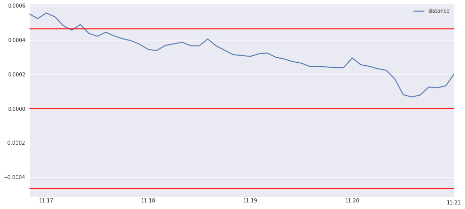

```python
mean.resam['distance'].dropna().plot(figsize=(15, 7), legend=True)
plt.axhline(threshold, color='r')
plt.axhline(-threshold, color='r')
plt.axhline(0, color='r');
```

## Risk Management & Capital Management

This section adresses the risk management and risk analysis of the trading strategy. At the first part we describe the strategy characteristics then upon those characteristics we decide how much leverage should we apply. then at the later parts, we calculate VaR figures coupled with tail-risk analysis.

#### Strategy Characteristics

One of the major factors which influence risk and return in the trading is the selection of algorithmic trading strategy itself. We argue, this is the most important risk management task. Below, we will first define the characteristic of the strategy.

```python
import tpqoa
```

```python
oanda = tpqoa.tpqoa('algotrader.pyg')
```

```python
import pandas as pd
```

```python
data = oanda.get_history('AUD_NZD',
                        start='2017-11-2',
                        end='2017-11-3',
                        granularity='S30',
                        price='A')['c']
```

```python
data = pd.DataFrame(data)
```

```python
data.columns = ['prices']
```

```python
data.fillna(0, inplace=True)
```

from here onwards, we resample the data into 30 second intervals and do the backtesting

```python
data = data.resample('30s').last().ffill()
```

```python
data.info()
```

```
<class 'pandas.core.frame.DataFrame'>
DatetimeIndex: 2880 entries, 2017-11-02 00:00:00 to 2017-11-02 23:59:30
Freq: 30S
Data columns (total 1 columns):
prices    2880 non-null float64
dtypes: float64(1)
memory usage: 45.0 KB
```

```python
data.tail()
```

| time | prices |
| --- | --- |
| 2017-11-02 23:57:30 | 1.11616 |
| 2017-11-02 23:58:00 | 1.11599 |
| 2017-11-02 23:58:30 | 1.11605 |
| 2017-11-02 23:59:00 | 1.11599 |
| 2017-11-02 23:59:30 | 1.11607 |

```python
import numpy as np
```

```python
data['returns'] = np.log(data['prices'] / data['prices'].shift(1))
```

```python
SMA = 138 # using half-life of mean reversion as SMA value
```

```python
data['SMA'] = data['prices'].rolling(SMA).mean()
```

```python
data['distance'] = data['prices'] - data['SMA']
```

```python
data['distance'].std() # this gives our treshold value
```

```
0.0004627014405625458
```

```python
threshold = 0.0004627014405625458
```

Mean reversion trades have been visualized below

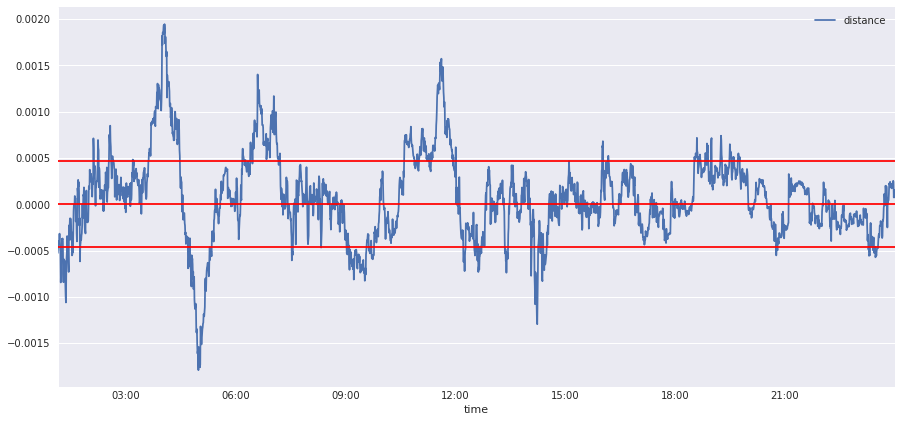

```python
data['distance'].dropna().plot(figsize=(15, 7), legend=True)
plt.axhline(threshold, color='r')
plt.axhline(-threshold, color='r')
plt.axhline(0, color='r');
```

We put our trading logic

```python
data['position'] = np.where(data['distance'] > threshold,-1, np.nan)
```

```python
data['position'] = np.where(data['distance'] < -threshold,1, data['position'])
```

```python
data['position'] = np.where(data['distance'] *data['distance'].shift(1) < 0, 0, data['position'])
```

```python
data['position'] = data['position'].ffill().fillna(0)
```

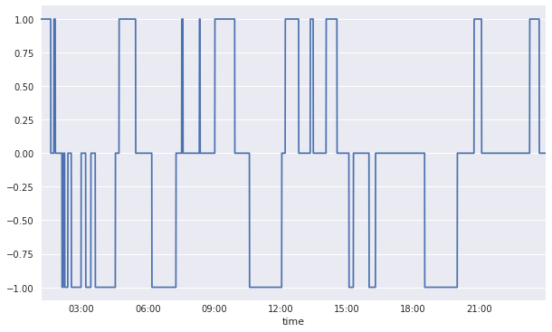

```python
data['position'].iloc[SMA:].plot(figsize=(10, 6)); # visualizing the positions (1=long, -1=short)
```

```python
data['strategy'] = data['position'].shift(1) * data['returns']
```

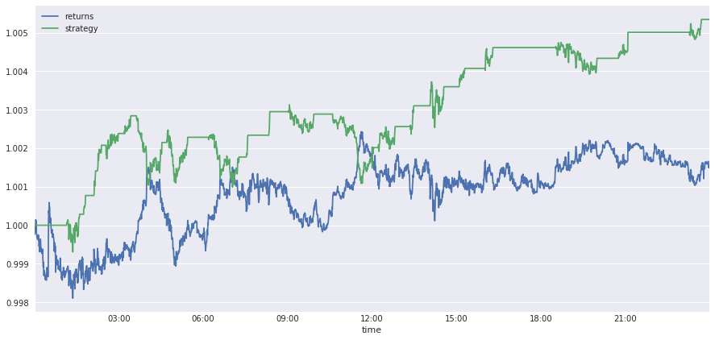

```python
data[['returns', 'strategy']].dropna().cumsum().apply(np.exp).plot(figsize=(15, 7)); # performance visualized
```

#### Basic Statistics of the strategy

```python
# annualized mean return
mean = data[['returns', 'strategy']].mean() * 2 * 60 * 24 * 252
mean
```

```
returns     0.395584
strategy    1.343486
dtype: float64
```

```python
# annualized variance
var = data[['returns', 'strategy']].var() * 2 * 60 * 24 * 252
var
```

```
returns     0.006545
strategy    0.002864
dtype: float64
```

```python
# annualized volatility
var ** 0.5
```

```
returns     0.080900
strategy    0.053519
dtype: float64
```

```python
# calculates optimal kelly criterion, which suggest how much capital should we allocate
mean / var
```

```
returns      60.442113
strategy    469.039257
dtype: float64
```

```python
mean / var * 0.5 # half kelly leverage
```

```
returns      30.221057
strategy    234.519628
dtype: float64
```

#### Leverage

```python
to_plot = ['returns', 'strategy']
```

```python
for l in [10, 20, 30, 40, 50]:
    label = 'lstrategy_%d' % l
    data[label] = data['strategy'] * l
    to_plot.append(label)
```

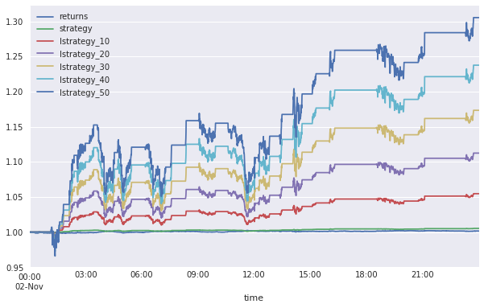

```python
# this polot shows leverage has a high impact on strategy performance
data[to_plot].cumsum().apply(np.exp).plot(figsize=(10, 6));
```

```python
# this code counts the long and short positions
data.position.value_counts()
```

```
 0.0    1610
-1.0     756
 1.0     514
Name: position, dtype: int64
```

```python
sum(abs(data.position.diff()) > 1.5) # this counts the number of trades
```

```
0
```

#### Resulting risk statistics

```python
risk = pd.DataFrame(data['lstrategy_30']) # we create a new dataframe object for risk analysis
```

```python
# calculates the new equity position over time given the leverage
risk['equity'] = risk['lstrategy_30'].cumsum().apply(np.exp) * 100000
```

```python
risk['cummax'] = risk['equity'].cummax() # cummulative maximum
```

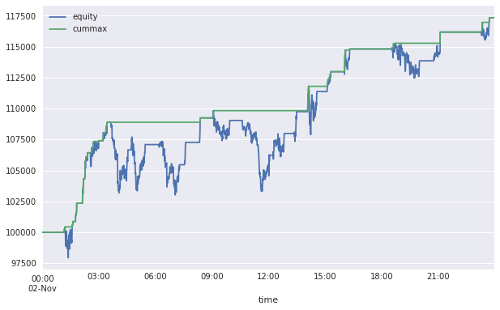

```python
# plots the evolution of the equity position and the running maximum over time given 30% leverage
risk[['equity', 'cummax']].plot(figsize=(10, 6));
```

```python
risk['drawdown'] = risk['cummax'] - risk['equity'] # calculates abosolute drawdown over time
```

```python
# identifying the maximum drawdown value, we found out that maximum drawdown is quite large to accept for an intraday strategy
risk['drawdown'].max()
```

```
6529.8882703795098
```

```python
# Identifies all those points in time where there is a new running maximum in the equity value.
temp = risk['drawdown'][risk['drawdown'] == 0]
```

```python
# Calculates the timedelta values for all those points.
periods = (temp.index[1:].to_pydatetime() -
           temp.index[:-1].to_pydatetime())
```

```python
# Identifies the longest period between two such points (in seconds)
t = periods.max()
```

```python
t # drawdown period in seconds
```

```
datetime.timedelta(0, 18030)
```

```python
# Transforms the seconds to hours.
t.seconds / 60 / 60 #drawdown period in hours
```

```
5.008333333333334
```

#### VaR (value at risk) analysis

Although the base data is not too large, we could still calculate and demonstrate VaR measures.

```python
# we use stats subpackage of Scipy
import scipy.stats as scs
```

```python
percs = [0.01, 0.1, 1., 2.5, 5.0, 10.0]
VaR = scs.scoreatpercentile(100000 - risk['equity'], percs) # we defined 90.0%, 95.0%, 97.5%, 99.0%, 99.9% confidence levels
```

```python
VaR.round(2) # prints the absolute loss values
```

```
array([-17337.39, -17337.39, -17337.39, -16175.97, -16175.97, -16175.97])
```

```python
# Prints confidence intervals and the positive VaR values (according to convention)
print("%16s %16s" % ('Confidence Level', 'Value-at-Risk'))
print(33 * "-")
for pair in zip(percs, VaR):
    print("%16.2f %16.3f" % (100 - pair[0], -pair[1]))
```

```
Confidence Level    Value-at-Risk
---------------------------------
           99.99        17337.390
           99.90        17337.390
           99.00        17337.390
           97.50        16175.969
           95.00        16175.969
           90.00        16175.969
```

#### Tail Risk

We can observe and identify tail risk as the largest negative return observed.

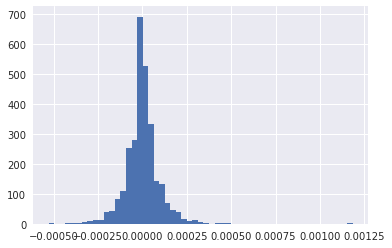

```python
data.returns.hist(bins=55);
```

```python
data.returns.min() # this gives us the largest negative return
```

```
-0.00052897008966234387
```

```python
data.returns.argmin() # this tells us when this worst return happened
```

```
Timestamp('2017-11-02 14:04:00', freq='30S')
```

```python
risk['lstrategy_30'].min() #This gives the lowest return given the time interval of the data set 30 seconds
```

```
-0.014792170311029657
```

```python
risk['lstrategy_30'].argmin() # This gives the time interval for which the lowest return is observed
```

```
Timestamp('2017-11-02 03:59:30', freq='30S')
```

## Conclusion

In addition, we have demonstrated the calculation of risk & capital parameters. We have calculated the Kely Criteria and demonstrated the effect of leverage. And at the last part we have concluded our analysis with the calculation of VaR and Tail Risk. We think that our sample time series data is far too little to give us an accurate risk metrics, and we believe securing such metrics in such a small sample data would not be reliable to implement an intra day trading strategy.

#### Sources

Coding of the necessary algorithm is hugely influenced by the Certificate Program in Algorithmic Trading with Python course material, also Dr.Yves Hilpisch's book "Python for Algorithmic Trading" and Ernest P.Chan "Algorithmic Trading" are used to implement the trading logic and statistical tests.